# Problem Set 5

Due date: 21 October

Please upload your completed assignment to the ELMs course site (under the assignments menu) and to your class Github repository. You need to upload both your Quarto document (with R code, as needed) and its rendered output (either as a PDF or HTML file).

**Total points: 25**

```r
library(tidyverse)
```

## Question 1

*Total points: 6*

Use the data in the table below to answer the following questions.

Voting by Age in 2000

| Age group | Non-voters | Voters | Total |
| --- | --- | --- | --- |
| 18-24 | 70 | 50 | 120 |
| 25-30 | 40 | 50 | 90 |
| 31 and up | 220 | 570 | 790 |
| TOTAL | 330 | 670 | 1000 |

### Part A

*Points: 2*

What is the probability of being 25-30 or a non-voter?

```r
(90 + 330 - 40)/1000
```

```
[1] 0.38
```

Answer: Probability is 0.38

### Part B

*Points: 4*

Assuming a normal distribution, report the 95% confidence intervals for the percentage of 18-to-24-year-olds who did not vote, and then the percentage of 25-to-30-year-olds who did not vote.

```r
(70/120) + 1.96*sqrt((70/120 * (1 - 70/120))/120)
```

```
[1] 0.6715434
```

```r
(70/120) - 1.96*sqrt((70/120 * (1 - 70/120))/120)
```

```
[1] 0.4951233
```

```r
(40/90) + 1.96*sqrt((40/90*(1-40/90))/90)
```

```
[1] 0.5471059
```

```r
(40/90) - 1.96*sqrt((40/90*(1-40/90))/90)
```

```
[1] 0.341783
```

The percentage of 18-24 year olds who did not vote had a 95% confidence interval of 49.51% to 67.15%

The percentage of 25-30 year olds who did not vote had a 95% confidence interval of 34.18% to 54.71%

## Question 2

*Total points:* *7*

Assume that the standard deviation for the population distribution of a state in which you want to conduct a poll is 200.

### Part A

*Points: 3*

Calculate the spread of the sampling distribution for each of the following sample sizes: 1, 4, 25, 100, 250, 1000, 5,000, and 10,000.

```r
sigma <- 200

n <- c(1, 4, 25, 100, 250, 1000, 5000, 10000)

SE <- sigma / sqrt(n)

results <- data.frame(
  Sample_Size = n,
  Standard_Error = round(SE, 2)
)

print(results)
```

```
  Sample_Size Standard_Error
1           1         200.00
2           4         100.00
3          25          40.00
4         100          20.00
5         250          12.65
6        1000           6.32
7        5000           2.83
8       10000           2.00
```

### Part B

*Points: 1*

Describe specifically how the variability of the sampling distribution changes as the sample size varies. Considering the expense of running a poll, which sample size do you think is most optimal if conducting the poll?

As the sample size increases, the variability decreases. Giving the expense of conducting a poll, 1000 would be a good sample size given that it can still provide a small standard error.

### Part C

*Points: 3*

Display your results graphically (using R) with the sample size on the x-axis and the standard error (of the sampling distribution) on the y-axis.

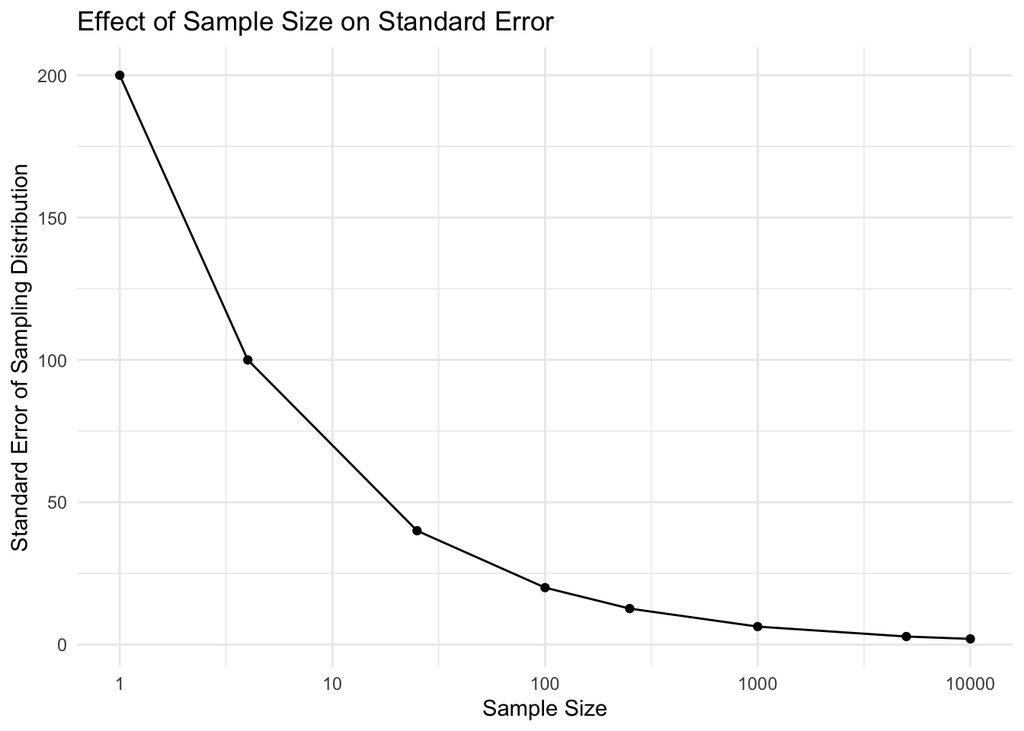

```r
ggplot(results, aes(x = Sample_Size, y = Standard_Error)) +
  geom_point() +
  geom_line() +
  scale_x_log10() +
  labs(
    title = "Effect of Sample Size on Standard Error",
    x = "Sample Size",
    y = "Standard Error of Sampling Distribution"
  ) +
  theme_minimal()
```

## Question 3

*Points: 4*

Suppose you conduct a survey (to generate a sample mean of interest) and find that it has a margin of error of 4.5 with a sample size of 900 using a 95% confidence interval. What would the margin of error be for a 90% confidence interval?

```r
n <- (4.5/1.96)*30

1.645*n/sqrt(900)
```

```
[1] 3.776786
```

Margin of Error would be 3.776786

## Question 4

*Points: 4*

Assume that, in State A, the mean income in the population is $20,000 with a standard deviation of $2,000. If you took an SRS of 900 individuals from that population, what is the probability that you would get a sample mean income of $20,200 or greater? What would be the probability if the sample size was only 25?

```r
n1<-2000/sqrt(900)
(20200-20000)/n1
```

```
[1] 3
```

```r
1-0.99865
```

```
[1] 0.00135
```

```r
n2 <- 2000/sqrt(25)
(20200-20000)/n2
```

```
[1] 0.5
```

```r
1-0.6915
```

```
[1] 0.3085
```

The probability for a sample of 900 would be 0.00135. The probability for a sample of 25 would b e 0.3085.

**Note**

Assume a normal distribution for both questions.

## Question 5

*Points: 4*

Assume that a coin is fair. If I flip a coin 500 times, what is a 95% confidence interval for the range of the count of heads that I will get? What if I flip the coin 5,000 times? What about 50,000 times?

```r
(0.5 + 1.96*sqrt(0.5*(1-0.5)/500)) * 500
```

```
[1] 271.9135
```

```r
(0.5 - 1.96*sqrt(0.5*(1-0.5)/500)) * 500
```

```
[1] 228.0865
```

```r
(0.5 + 1.96*sqrt(0.5*(1-0.5)/5000)) * 5000
```

```
[1] 2569.296
```

```r
(0.5 - 1.96*sqrt(0.5*(1-0.5)/5000)) * 5000
```

```
[1] 2430.704
```

```r
(0.5 + 1.96*sqrt(0.5*(1-0.5)/50000)) * 50000
```

```
[1] 25219.13
```

```r
(0.5 - 1.96*sqrt(0.5*(1-0.5)/50000)) * 50000
```

```
[1] 24780.87
```

For 500 times the interval would be 228 through 272. For 5000 times the interval would be 2431 to 2569. For 50000 times the interval would be 24781 to 25219.